# IODS course project

# About the project

Introduction to Open Data Science is a MOOC (Massive Open Online Course) hosted by the University of Helsinki: http://mooc.helsinki.fi

*After completing this course you will understand the principles and advantages of using open research tools with open data and understand the possibilities of reproducible research. You will know how to use R, RStudio, RMarkdown, and GitHub for these tasks and also know how to learn more of these open software tools. You will also know how to apply certain statistical methods of data science, that is, data-driven statistics.*

A link to my GitHub repository for this course: https://github.com/jootenhu/IODS-project

# Regression and model validation

The theme for the first exercise is regression analysis. Data set was survey results from introductory level statistics course, and was about learning approaches.

First the data had to be preprocessed for further analysis. By combining questions in the data, scaling combination variables, and excluding some observations, end result was learning2014.cvs

```r
learning2014 <- read.csv("data/learning2014.csv", header = TRUE, sep=",")

#print out structure of dataset
str(learning2014)
```

```
## 'data.frame':    166 obs. of  7 variables:
##  $ Gender  : Factor w/ 2 levels "F","M": 1 2 1 2 2 1 2 1 2 1 ...
##  $ Age     : int  53 55 49 53 49 38 50 37 37 42 ...
##  $ Attitude: num  3.7 3.1 2.5 3.5 3.7 3.8 3.5 2.9 3.8 2.1 ...
##  $ Points  : int  25 12 24 10 22 21 21 31 24 26 ...
##  $ Deep    : num  3.58 2.92 3.5 3.5 3.67 ...
##  $ Stra    : num  3.08 3.25 3.42 2.83 3.58 ...
##  $ Surf    : num  2.58 3.17 2.25 2.25 2.83 ...
```

```r
head(learning2014)
```

```
##   Gender Age Attitude Points     Deep     Stra     Surf
## 1      F  53      3.7     25 3.583333 3.083333 2.583333
## 2      M  55      3.1     12 2.916667 3.250000 3.166667
## 3      F  49      2.5     24 3.500000 3.416667 2.250000
## 4      M  53      3.5     10 3.500000 2.833333 2.250000
## 5      M  49      3.7     22 3.666667 3.583333 2.833333
## 6      F  38      3.8     21 4.750000 3.333333 2.416667
```

learning2014.csv consists of 166 observations and 7 variables which are:

- gender
- age
- attitude towards statistics in general
- exam points

and the three learning approaches

- deep
- strategic
- surface

## Summary of variables

```r
summary(learning2014)
```

```
##  Gender       Age           Attitude         Points           Deep
##  F:110   Min.   :17.00   Min.   :1.400   Min.   : 7.00   Min.   :1.583
##  M: 56   1st Qu.:21.00   1st Qu.:2.600   1st Qu.:19.00   1st Qu.:3.333
##          Median :22.00   Median :3.200   Median :23.00   Median :3.667
##          Mean   :25.51   Mean   :3.143   Mean   :22.72   Mean   :3.680
##          3rd Qu.:27.00   3rd Qu.:3.700   3rd Qu.:27.75   3rd Qu.:4.083
##          Max.   :55.00   Max.   :5.000   Max.   :33.00   Max.   :4.917
##       Stra            Surf
##  Min.   :1.750   Min.   :1.583
##  1st Qu.:2.750   1st Qu.:2.417
##  Median :3.167   Median :2.833
##  Mean   :3.117   Mean   :2.787
##  3rd Qu.:3.500   3rd Qu.:3.167
##  Max.   :4.333   Max.   :4.333
```

## A matrix of scatterplots

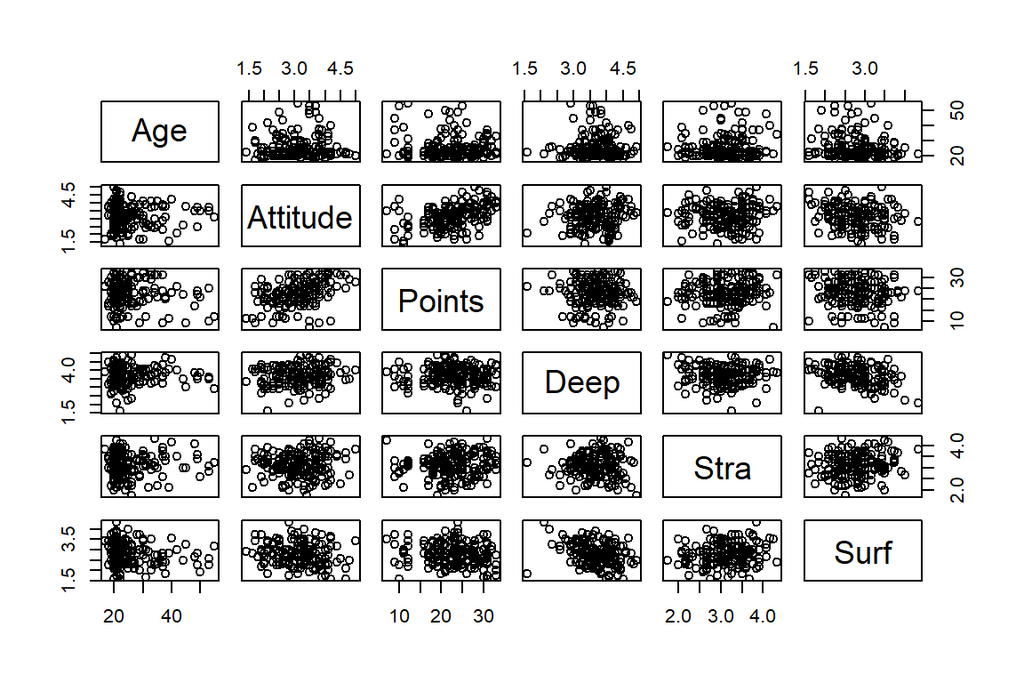

```r
pairs(learning2014[-1])
```

Age tends to be on the lower side, and there are no clear correlation in any of the pairs. There is interesting gap in the Points variable around value of 15.

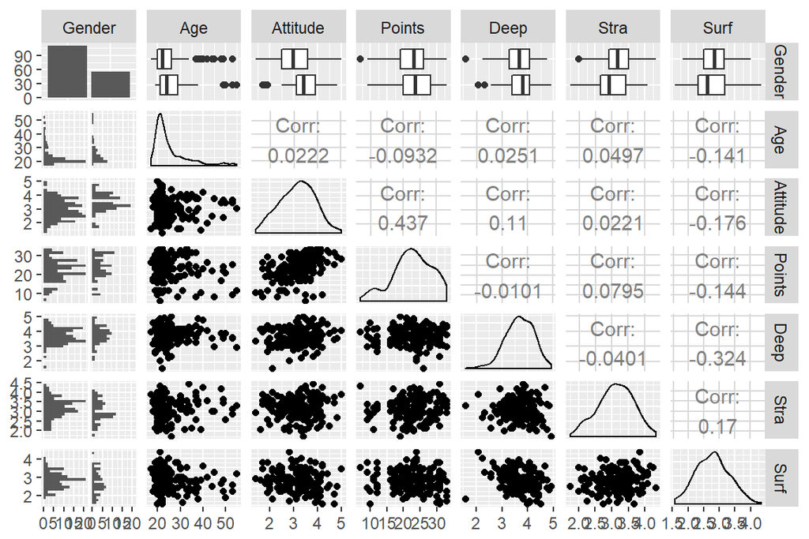

```r
library(GGally)
library(ggplot2)

ggpairs(learning2014, lower = list(combo = wrap("facethist", bins = 20)))
```

There are no big correlations between variables, biggest being with Attitude and Points (0.437). Distributions seems quite normally distributed with the exception of Age wich is positively skewed. The gap in the Points variable deforms the distribution some.

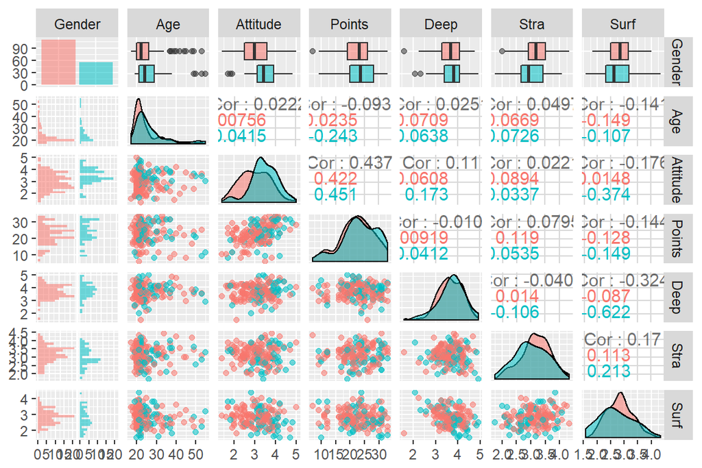

```r
ggpairs(learning2014, mapping = aes(col = Gender, alpha = 0.3), lower = list(combo = wrap("facethist", bins = 20)))
```

When data is split with the gender stronger correlation (-0.622) is found between Deep and Surf variables in the male responses. With female responses this is -0.087.